# Software Tools for Earth and Environmental Science

Emir Toker

14/11/2019

## **R Promgramming - Part 2**

- **Syllabus and Book**
- **DataCamp Class**
- **Practice - Assessment Test**
- **R Advance - *ncdf4* & *RNetCDF* Packages**

**Coffee Break**

- **R Statistics - *hist, summary, etc.* functions**
- **R Advance - *ggplot2* Package**

**QUIZ**

- **Next Week**

# **Syllabus and Book**

## **Syllabus**

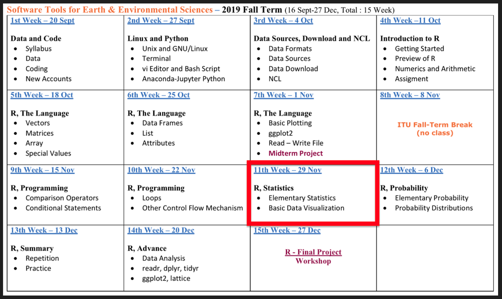

## **Book**

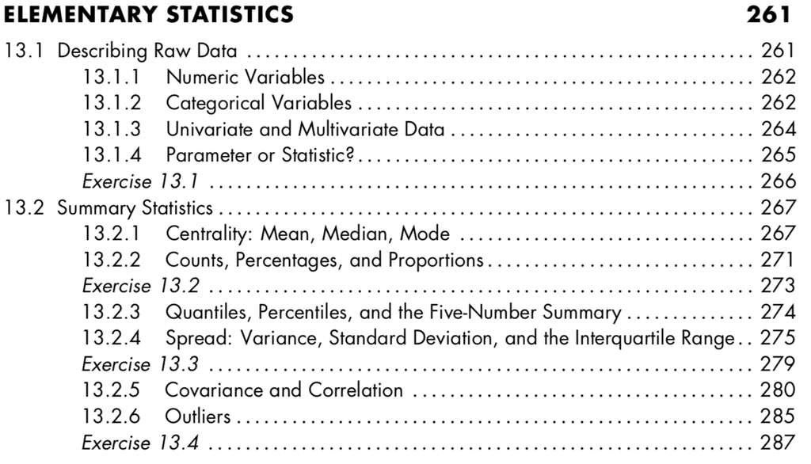

## **Book**

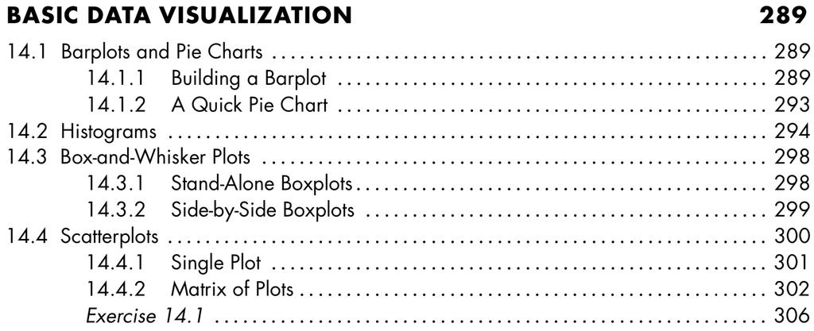

# **DataCamp Class**

## **DataCamp Class**

[figure not shown]

[LINK](https://www.datacamp.com/enterprise/software-tools-introduction-to-r)

# **Practice - Assessment Test**

## **Practice - Assessment Test**

1. Open Your R-Studio :)
2. Create a new **“R Project”**
3. Create a new **“R Script”** file and save it
4. Learn your **Working Directory**
5. Check **files**, under your working directory
6. Create a **vector** with four **numeric** elements using **seq()**
7. **Assign** it to a new variable *(vec1)*
8. Check the **length** of vector
9. Calculate the **mean** of vector
10. Coerce your **numeric** vector to **characteristic** vector
11. Check the **class** of your new vetcor
12. **Print** the second element of your vector
13. **Change** the second element as “TRUE”, and assign it as *vec1*

## **Practice - Assessment Test**

14. Create a new **vector** with 12 elements using **runif()**
15. Assign it as *vec2*
16. Create a new **matrix**, 3 rows, 4 columns using this vector
17. **Assign** this matrix as a new variable
18. Check **dimensions** of this matrix
19. Create a new matrix (4x4) with using *vec1* and *vec2*
20. Explain what is happening (bycol or byrow)
21. Create the same matrix again, this time with **byrow=T**
22. Assign it as *mat1*
23. Create a new **array** with 4 rows, 4 columns and 2 layers using *mat1*
24. Assign it as *arr1*
25. **Select** 2nd row, 3rd column and change it with *NA* for each layers

## **Practice - Assessment Test**

26. Go to main web page of our course
27. Copy this data : Istanbul_Cekmekoy_Omerli_26072017-29072017_15min - txt
28. Paste your **“Download”** folder
29. Turn back to R Studio
30. **Read** the station data, be careful about file **path**, **header** and **seperator**
31. Assign it as **sta_data**
32. Check the **structure** and **attributes** of **sta_data**
33. **Print** and **plot** *precipiptation* of *sta_data*
34. Write a **condition**; **if** total precipitation is **higher** than zero than **print** “Weather was rainy”
35. Install and load “ncdf4” and “RNetCDF” package

## NETCDF

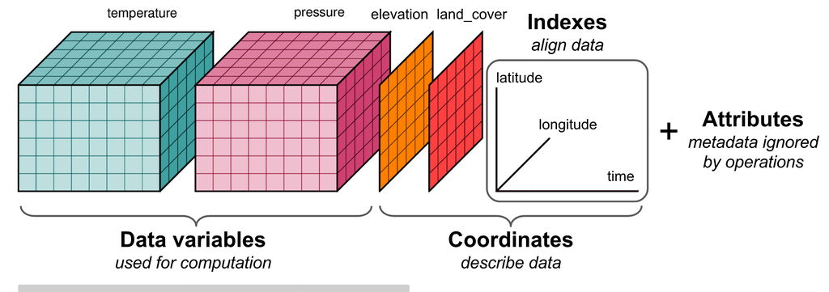

# **R Advance - *ncdf4* & *RNetCDF* Packages**

## **R Advance - *ncdf4* Package**

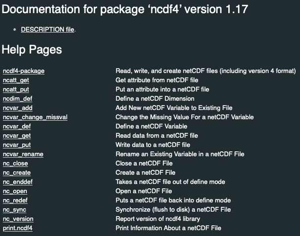

## **R Advance - *ncdf4* Package**

- ncdf4_open <- **nc_open**(“cru_1901_2012_tmp_TR.nc”)

```
> ncdf4_open <- nc_open("cru_1901_2012_tmp_TR.nc")
> ncdf4_open

File ~/Desktop/Dersler/Yüksek_Lisans_Ders/Data Analysis/proje/Data_Analysis_Proje/cru_1901_2012_tmp_TR.nc (NC_FORMAT_CLASSIC):

     1 variables (excluding dimension variables):
        double tmp[lon,lat,time]
            long_name: near-surface temperature
            units: degrees Celsius
            _FillValue: 9.96920996838687e+36
            missing_value: 9.96920996838687e+36
            correlation_decay_distance: 1200

     3 dimensions:
        lon  Size:42
            standard_name: longitude
            long_name: longitude
            units: degrees_east
            axis: X
        lat  Size:18
            standard_name: latitude
            long_name: latitude
            units: degrees_north
            axis: Y
        time  Size:1344   *** is unlimited ***
            standard_name: time
            long_name: time
            units: days since 1900-01-01 00:00:00
            calendar: standard

    10 global attributes:
        CDI: Climate Data Interface version 1.6.9 (http://mpimet.mpg.de/cdi)
        Conventions: CF-1.4
        history: Mon Feb 22 16:24:47 2016: cdo sellonlatbox,25,46,34,43 cru_ts3.21.1901.2012.tmp.dat.nc cru_1901_2012_tmp_TR.nc
Wed 10 Jul 2013 17:04:15 BST : User ianharris : Program makegridsauto.for called by update.for
        source: Run ID = 1307101324
Data generated by BADC from:
tmp.1307101049.dtb
        institution: Data held at British Atmospheric Data Centre, RAL, UK.
        title: CRU TS3.21 Mean Temperature
        references: Information on the data is available at http://badc.nerc.ac.uk/data/cru/
        comment: Data restrictions: for academic research use only.Contact BADC for details
        contact: BADC <badc@rl.ac.uk>
        CDO: Climate Data Operators version 1.7.0rc2 (http://mpimet.mpg.de/cdo)
```

## **R Advance - *RNetCDF* Package**

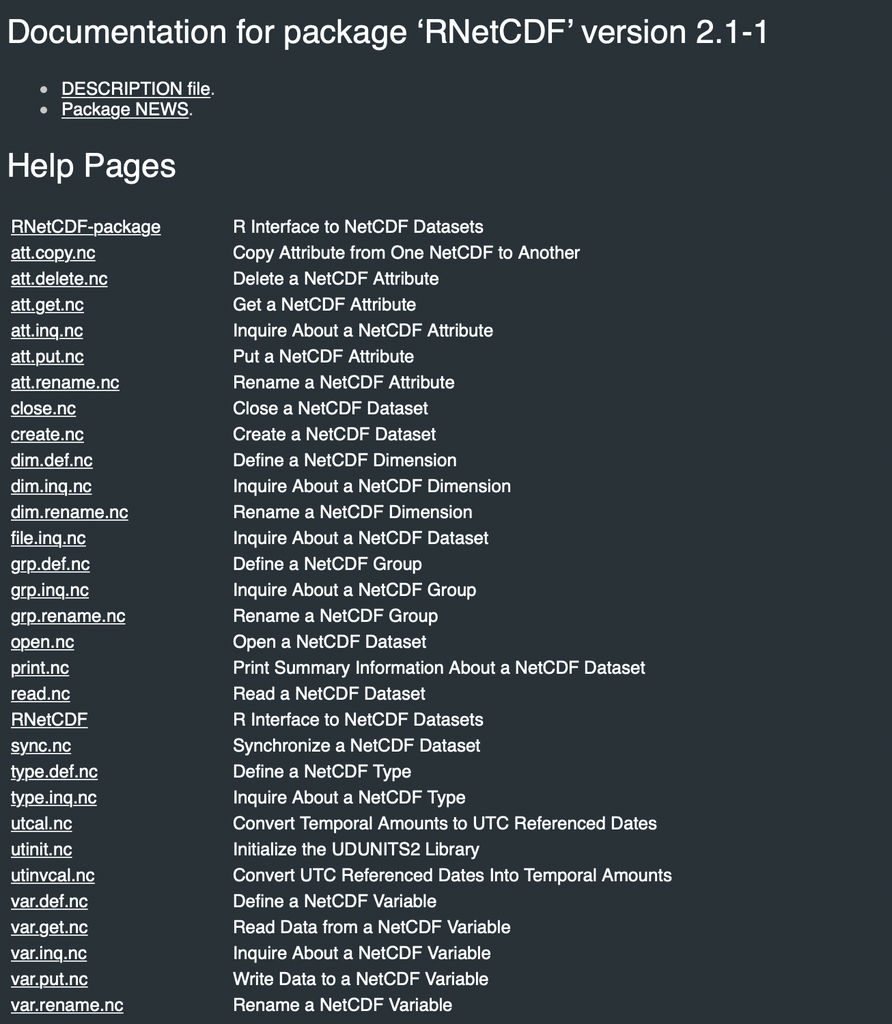

## **R Advance - *RNetCDF* Package**

- rnetcdf_open <- **open.nc**(“cru_1901_2012_tmp_TR.nc”)
- **print**(rnetcdf_open)

```
> rnetcdf_open <- open.nc(veri.ad)
> print.nc(rnetcdf_open)

netcdf classic {
dimensions:
    lon = 42 ;
    lat = 18 ;
    time = UNLIMITED ; // (1344 currently)
variables:
    NC_DOUBLE lon(lon) ;
        NC_CHAR lon:standard_name = "longitude" ;
        NC_CHAR lon:long_name = "longitude" ;
        NC_CHAR lon:units = "degrees_east" ;
        NC_CHAR lon:axis = "X" ;
    NC_DOUBLE lat(lat) ;
        NC_CHAR lat:standard_name = "latitude" ;
        NC_CHAR lat:long_name = "latitude" ;
        NC_CHAR lat:units = "degrees_north" ;
        NC_CHAR lat:axis = "Y" ;
    NC_DOUBLE time(time) ;
        NC_CHAR time:standard_name = "time" ;
        NC_CHAR time:long_name = "time" ;
        NC_CHAR time:units = "days since 1900-01-01 00:00:00" ;
        NC_CHAR time:calendar = "standard" ;
    NC_DOUBLE tmp(lon, lat, time) ;
        NC_CHAR tmp:long_name = "near-surface temperature" ;
        NC_CHAR tmp:units = "degrees Celsius" ;
        NC_DOUBLE tmp:_FillValue = 9.96920996838687e+36 ;
        NC_DOUBLE tmp:missing_value = 9.96920996838687e+36 ;
        NC_DOUBLE tmp:correlation_decay_distance = 1200 ;

// global attributes:
        NC_CHAR :CDI = "Climate Data Interface version 1.6.9 (http://mpimet.mpg.de/cdi)" ;
        NC_CHAR :Conventions = "CF-1.4" ;
        NC_CHAR :history = "Mon Feb 22 16:24:47 2016: cdo sellonlatbox,25,46,34,43 cru_ts3.21.1901.2012.tmp.dat.nc cru_1901_2012_tmp_TR.nc
Wed 10 Jul 2013 17:04:15 BST : User ianharris : Program makegridsauto.for called by update.for" ;
        NC_CHAR :source = "Run ID = 1307101324
Data generated by BADC from:
tmp.1307101049.dtb" ;
        NC_CHAR :institution = "Data held at British Atmospheric Data Centre, RAL, UK." ;
        NC_CHAR :title = "CRU TS3.21 Mean Temperature" ;
        NC_CHAR :references = "Information on the data is available at http://badc.nerc.ac.uk/data/cru/" ;
        NC_CHAR :comment = "Data restrictions: for academic research use only.Contact BADC for details" ;
        NC_CHAR :contact = "BADC <badc@rl.ac.uk>" ;
        NC_CHAR :CDO = "Climate Data Operators version 1.7.0rc2 (http://mpimet.mpg.de/cdo)" ;
}
```

## R Advance - *ncdf4* VS *RNetCDF*

```
- class(my_nc)
- str(my_nc)
- attributes(my_nc)
- attributes(my_nc$var)
- attributes(my_nc$var$t2m)

- my_nc$var$t2m$longname
- my_nc$var$t2m$name
- my_nc$var$t2m

- ncatt_get(my_nc,'t2m')
```

```
- ncvar_get(my_nc,my_nc$var$t2m$name)
- ncvar_get(my_nc,"t2m")
-

- class(temp)
- dim(temp)
- str(temp)

- attributes(my_nc)
- attributes(my_nc$dim)
- lon <- ncvar_get(my_nc, my_nc$dim$lon)
- lat <- ncvar_get(my_nc, my_nc$dim$lat)
- time <- ncvar_get(my_nc, my_nc$dim$time)
```

[output not shown]

## **R Advance - *ncdf4* Package**

```
- ncatt_get(my_nc,"time")
```

# **Coffee Break**

# **R Statistics - *hist, summary, etc.* functions**

## **R Statistics - *hist, summary, etc.* functions**